# My Assignment 3 Title (.)

Elizabeth Riese, Id 1003106122

November 27, 2020

## I. Data Wrangling

150 random samples from the real estate data set were generated and their respective ID numbers are reported below.

```
##   [1] 188  49 229  31  70  23  52 167 104 135  14  13  45 165 174   2  87 134
##  [19]  58 162 119  27 100  10 116 103 173 146  41  38  48  12  65  89  99 218
##  [37]  90 171  34  29 114  36  46 156 163 205  28 169  88 126 113 196  43  68
##  [55]  91 122 140 152 164 166 153  19 143  26  94  22  55  96 101  71 109   7
##  [73] 194  35 131 108 186  32  17 190 144 180 154  62  80   4 125 141 145 177
##  [91]  57 136 189  95 105  21  30 157 175 168  78 227  53  50 185 149 181 191
## [109]  42 115  15 160  44 195 204  79 176   8  76 117  37  25 193  16 107  40
## [127] 150 147  92  56 106  20  85  84 179  64 102 137 201  97  54 158   6  93
## [145] 159  39  69  98 172 118
```

I. c) For the regression to make sense we would have to remove the identification number as this doesn’t really have anything to do with the properties’ valuation. The ID number exists only to make the properties clearly distinguishable from one another. Each number is unique so there is no pattern to observe.

It also appears that the max square footage predictor variable is missing a lot values at a first glance. Using Rstudio to check how many exactly are missing it seems that only 64 values don’t have a missing max square footage value. This is less than half the total intended 150 values intended to be used for this report so it would make sense to just not use this variable at all since the missing values will make regression analysis results inaccurate.

There appeared to be some other missing values not from the max square footage variable when looking at the data set. After counting these there seemed to be 9 other missing values in total which is within the 11 limit we are allowed to remove. Consequently a subset of the data without these points was created which was used for this report and has 141 complete data values.

## II. Exploratory Data Analysis

Classifying Variables as Discrete or Continuous

• sale: the actual sale price of the property in Canadian dollars This variable is discrete. Note: Although price is measured in numeric dollars, all currencies have a limited fraction of which they can be divided into which makes them a discrete measurement; compared to that of height or mass that can always have infinitesimally smaller increments which is what makes them continuous.

• list: the last list price of the property in Canadian dollars This variable is discrete.

• bedroom: the total number of bedrooms This variable is discrete.

• bathroom: the number of bathrooms This variable is discrete.

• parking: the total number of parking spots This variable is discrete.

• maxsqfoot: the maximum square footage of the property This variable is continuous. Note: The measurements used to create this variable are lengths, which is a physical property that has infinitesimally smaller increments despite any limitations of the smallest increments of the measuring tool used to find said lengths. For that reason this variable is continuous.

• taxes: previous year’s property tax This variable is discrete.

• lotsize: the length in feet of one side of the property multiplied by the frontage in feet This variable is continuous.

• location: M - Mississauga Neighbourhood, T - Toronto Neighbourhood, This variable is categorical.

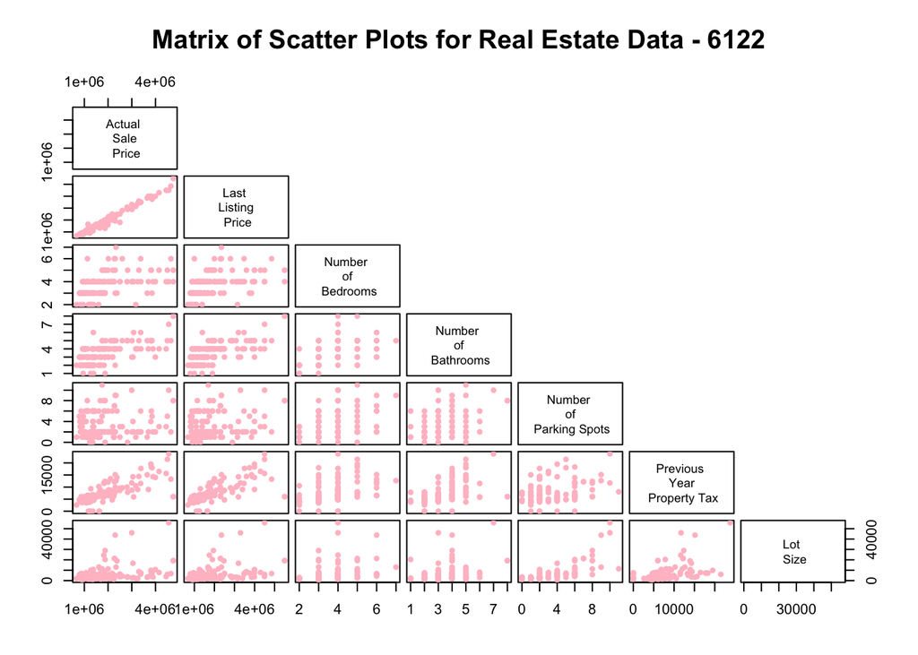

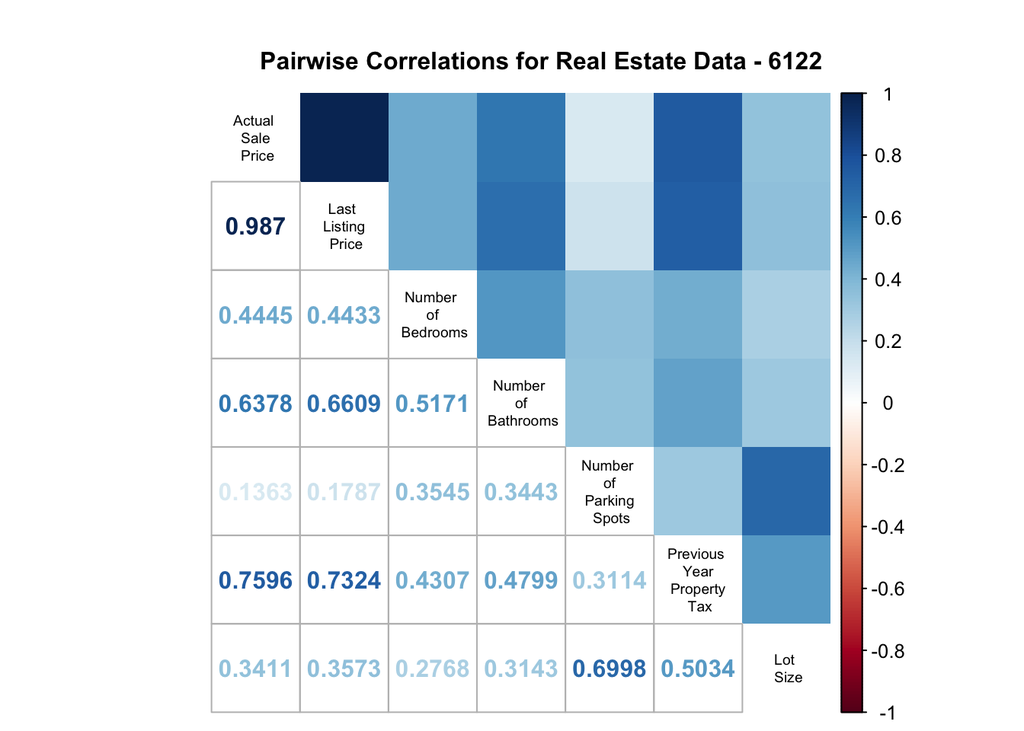

2. 2. A Note on Interpreting the Matrix: The darker the color the higher the correlation. Blue indicates a positive correlation from 0 to 1 and red indicates a negative correlation from 0 to -1. The lower part shows the numeric values while the upper part shows the same information but just as shades of color. The scale is on the right hand side of the matrix.

Correlation Coefficients Ranked from Highest to Lowest

Sale Price / Last Listing Price : 0.9870 Sale Price / Previous Year Property Tax : 0.7596 Sale Price / Number of Bathrooms : 0.6378 Sale Price / Number of Bedrooms : 0.4445 Sale Price / Lot Size : 0.3411 Sale Price / Number of Parking Spots : 0.1363

The highest correlation seem to be between the actual sale price and the listing price. It seems to be significantly higher than all the other correlation coefficients. Property tax and number of bathrooms appear to both be quite high values and close but not as much as last listing price. Number of bedrooms, lot size and number of parking spots seem to be quite low as they are all less than 0.5 (50% correlation).

2. 3. For constant variance the distance of the points in the scatter plot, or the distribution around a linear trend, should be somewhat the same. At a glance it seems that quite difficult to tell which single predictor variable this is. After zooming in on the distributions it would seem that lot size does not have constant variance. This can also be checked by plotting the residuals against the fitted values and observing the variance of the points.

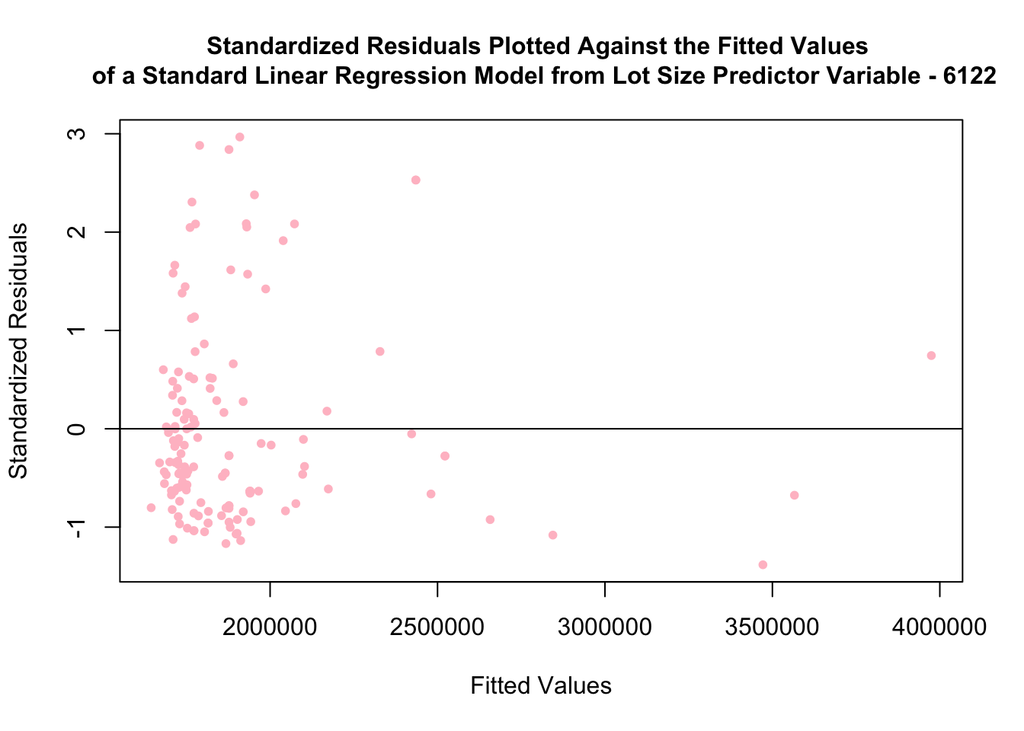

From the standardized residual plot it seems that the points are not evenly distributed around the zero center line. The values seem much higher above than below the zero line and they are mainly clustered to the left. This confirms that there is violation of the constant variance assumption.

## III. Methods and Model

```
##
## Call:
## lm(formula = sample1$sale ~ sample1$list + sample1$bedroom +
##     sample1$bathroom + sample1$parking + sample1$taxes + sample1$lotsize +
##     sample1$location)
##
## Residuals:
##     Min      1Q  Median      3Q     Max
## -398555  -74667  -13679   75924  566572
##
## Coefficients:
##                    Estimate Std. Error t value Pr(>|t|)
## (Intercept)       5.476e+04  5.923e+04   0.925    0.357
## sample1$list      8.288e-01  2.159e-02  38.385  < 2e-16 ***
## sample1$bedroom   1.567e+04  1.489e+04   1.052    0.295
## sample1$bathroom  4.287e+03  1.407e+04   0.305    0.761
## sample1$parking  -1.506e+04  9.169e+03  -1.643    0.103
## sample1$taxes     2.299e+01  4.456e+00   5.160 8.79e-07 ***
## sample1$lotsize   1.712e+00  2.311e+00   0.741    0.460
## sample1$location  9.746e+04  4.034e+04   2.416    0.017 *
## ---
## Signif. codes:  0 '***' 0.001 '**' 0.01 '*' 0.05 '.' 0.1 ' ' 1
##
## Residual standard error: 137500 on 133 degrees of freedom
## Multiple R-squared:  0.9814, Adjusted R-squared:  0.9804
## F-statistic:  1002 on 7 and 133 DF,  p-value: < 2.2e-16
```

Table of Slope Estimate Values and their Respective P-Values - 6122

```
##                            Slope Estimates P-Values
## Last Listing Price                  0.8288   0.0000
## Number of Bedrooms              15669.5113   0.2946
## Number of Bathrooms              4287.3527   0.7610
## Number of Parking Spots        -15063.7199   0.1028
## Previous Year Property Tax         22.9939   0.0000
## Lot Size                            1.7121   0.4602
## Location                        97460.6846   0.0170
```

The benchmark significance level used for this report was 5% (or 0.05). Only three predictor variables had a value less than 0.05 indicating that they are significant; these were last listing price, previous year’s property tax and location.

For these significant values, it is indicative that we may draw conclusions from the MLR model created.

There is a 97460.6846 dollar difference expected between properties in Toronto versus Mississauga

```
## [1] 3746.438
```

This is the AIC value for the full model. The number of the bathrooms variable has the highest p-value so this is the first variable to be removed.

A regression model was created for each of the highest respective p-value predictor variables removed as instructed. The summary of the regression was omitted but tables were created with the relevant results and AIC values so it would be easier to read.

```
##                            Slope Estimates     P-Values
## Last Listing Price                  0.8325 2.949808e-85
## Number of Bedrooms              16963.7481 2.352044e-01
## Number of Parking Spots        -14989.9281 1.031549e-01
## Previous Year Property Tax         22.8576 8.222479e-07
## Lot Size                            1.6260 4.782242e-01
## Location                        94077.0789 1.624341e-02
```

```
## [1] 3744.536
```

```
##                            Slope Estimates     P-Values
## Last Listing Price                    0.83 3.513412e-86
## Number of Bedrooms                15592.83 2.697081e-01
## Number of Parking Spots          -12051.62 1.406823e-01
## Previous Year Property Tax           23.77 9.819126e-08
## Location                          91158.59 1.888649e-02
```

```
## [1] 3743.067
```

```
##                            Slope Estimates     P-Values
## Last Listing Price                  0.8377 6.264678e-88
## Number of Parking Spots         -9937.1206 2.112795e-01
## Previous Year Property Tax         24.2379 5.156798e-08
## Location                        94107.6248 1.526357e-02
```

```
## [1] 3742.344
```

```
##                            Slope Estimates     P-Values
## Last Listing Price                  0.8327 1.913794e-89
## Previous Year Property Tax         23.3907 9.909790e-08
## Location                       130904.4060 4.609847e-07
```

```
## [1] 3741.97
```

```
##                            Slope Estimates     P-Values
## Last Listing Price                  0.8590 3.775717e-89
## Previous Year Property Tax         18.5521 5.067809e-05
```

```
## [1] 3766.227
```

It appears that the minimum predictor values are last listing price, previous year property tax, and location. This is because the AIC value only gets higher once we remove location.

Therefore the final model would be:

```
##
## Call:
## lm(formula = sample1$sale ~ sample1$list + sample1$taxes + sample1$location)
##
## Residuals:
##     Min      1Q  Median      3Q     Max
## -414856  -76811  -12475   74967  590320
##
## Coefficients:
##                   Estimate Std. Error t value Pr(>|t|)
## (Intercept)      5.760e+04  2.806e+04   2.052    0.042 *
## sample1$list     8.327e-01  1.678e-02  49.631  < 2e-16 ***
## sample1$taxes    2.339e+01  4.156e+00   5.628 9.91e-08 ***
## sample1$location 1.309e+05  2.472e+04   5.295 4.61e-07 ***
## ---
## Signif. codes:  0 '***' 0.001 '**' 0.01 '*' 0.05 '.' 0.1 ' ' 1
##
## Residual standard error: 137200 on 137 degrees of freedom
## Multiple R-squared:  0.9809, Adjusted R-squared:  0.9805
## F-statistic:  2347 on 3 and 137 DF,  p-value: < 2.2e-16
```

final sale price = 57600 + 0.8327(last listing price) + 23.39(previous year’s property tax) + 130900(location)

This is similar to the original model, however all the predicted coefficients are slightly higher, and the location coefficient is much higher with it enter the 10^5 magnitude versus the 10^4 magnitude.

3. 3. The order of the predictor variables from smallest to largest: listing price, previous year’s property taxes, location, parking, number of bedrooms, lot size, number of bathrooms.

```
##                    Slope Estimates      P-Values
## Last Listing Price          0.9127 3.759756e-112
```

```
## [1] 3781.067
```

```
##                            Slope Estimates     P-Values
## Last Listing Price                  0.8590 3.775717e-89
## Previous Year Property Tax         18.5521 5.067809e-05
```

```
## [1] 3766.227
```

```
##                            Slope Estimates     P-Values
## Last Listing Price                  0.8327 1.913794e-89
## Previous Year Property Tax         23.3907 9.909790e-08
## Location                       130904.4060 4.609847e-07
```

```
## [1] 3741.97
```

```
##                            Slope Estimates     P-Values
## Last Listing Price                  0.8377 6.264678e-88
## Number of Parking Spots         -9937.1206 2.112795e-01
## Previous Year Property Tax         24.2379 5.156798e-08
## Location                        94107.6248 1.526357e-02
```

```
## [1] 3742.344
```

Here the AIC value has risen again as expected and we get the same conclusions from part III. ii) about the minimum number of variables needed for this specific regression; that being, last listing price, previous year’s property tax and location. We also see the values differ from part III. i) as expected and in the same way the results in the second part deviate from the first.

## IV. Discussions and Limitations

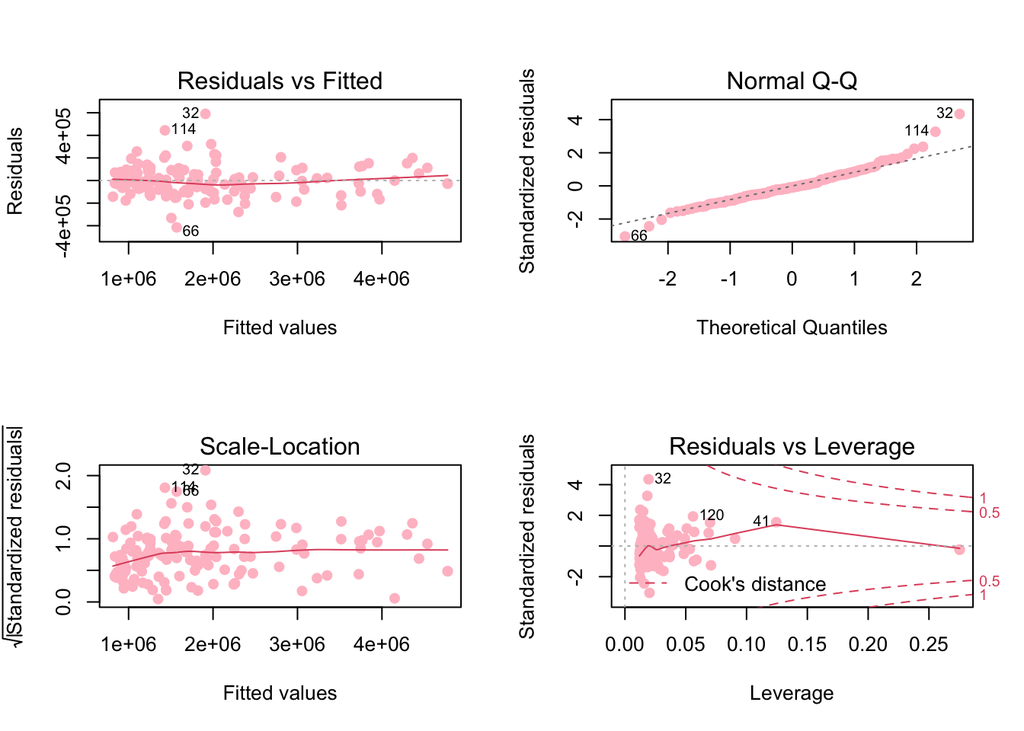

Residual vs Fitted Values

The red line is almost completely horizontal which implies that a linear fit would be appropriate for this data. The majority of values appear to have a constant variance, however there are about three points that the plot function marked out (32, 66, 114) that seemed to deviate from the middle line significantly so they are most likely outliers. The points also seem to cluster to the left then become less frequent towards the right but overall they appear to have similar variances so it would be appropriate to say that the homoscedasticity assumption holds.

Scale-Location

The red line is approximately horizontal with only a dip on the left side of the line. It would be appropriate to say that a linear fit is appropriate for this data. The data seems to be more frequent on the left of the plot then less so on the right, but this is only slightly. The overall spread of the data seems to be randomly distributed around the center line with roughly equal variability. There are three outlying points, 32, 114 and 66 just as found in the residual vs fitted values plot. This is a strong indication that they may be outlying points.

QQ-Plot of Standardized Residuals

It seems the the residuals do follow a normal pattern as they are mostly on the line with only deviation in the tails of a few points. This may indicate they aren’t exactly normal, but it appears that the plot function has marked a few of these tail points as outliers; specifically 32, 114 and 66 again. For the most part the points seem to be right on the line so it would be fair to say that the assumption of normally distributed residuals holds.

Residual vs. Leverage

There doesn’t appear to be any points that lie outside the calculated cooks distance so that would mean there aren’t any leverage points that would significantly affect the results of the data.

4. 3. It seems that this reduced model does seem to hold the assumptions required for MLR according to the t-tests from the regression and the plots of the diagnostic plots of the residuals. One could go further and perform extra tests to confirm the conclusions made from diagnostic plots with specific values from the results of these tests. It would also be appropriate to use the final model to create a confidence interval of the predicted values.